Griffin Shelor  
24-4-2024

# In-class Exercise: Supervised Learning 2

```python
# Import packages
import matplotlib.pyplot as plt
from sklearn.model_selection import train_test_split
from sklearn.linear_model import LogisticRegression
from sklearn.ensemble import RandomForestClassifier
from sklearn.metrics import accuracy_score
from sklearn.datasets import load_digits
```

### For this in-class exercise, we'll be working with the classification of hand-written digits (numbers).

```python
# Load the dataset
digits = load_digits()
```

```python
# Function to plot data
def plot_digit(digits, i):
    plt.figure(figsize=(2, 2))
    plt.imshow(digits.images[i], cmap='binary', interpolation='nearest')
    plt.xticks([])
    plt.yticks([])
    plt.text(8, 0.1, str(digits.target[i]), color='green', fontsize=16)
```

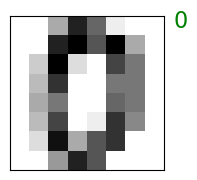

```python
# Example plot
plot_digit(digits,0)
```

### We will work with a 'flattened' array e.g., instead of 8x8 grid use a 64x1 grid. `scikit-learn` has provided this for us. We will set up the feature and target arrays.

```python
X_digits = digits.data
y_digits = digits.target
```

### Q1. Make 5 different pairs of training and test datasets, with the following characteristics:

1. Use a `train_size` of 0.9, `random_state` = 15
2. Use a `train_size` of 0.8, `random_state` = 15
3. Use a `train_size` of 0.7, `random_state` = 15
4. Use a `train_size` of 0.6, `random_state` = 15
5. Use a `train_size` of 0.5, `random_state` = 15

```python
# train/test split (90/10)
Xtrain1, Xtest1, ytrain1, ytest1 = train_test_split(X_digits, y_digits, train_size=0.9, random_state=15)
# train/test split (80/20)
Xtrain2, Xtest2, ytrain2, ytest2 = train_test_split(X_digits, y_digits, train_size=0.8, random_state=15)
# train/test split (70/30)
Xtrain3, Xtest3, ytrain3, ytest3 = train_test_split(X_digits, y_digits, train_size=0.7, random_state=15)
# train/test split (60/40)
Xtrain4, Xtest4, ytrain4, ytest4 = train_test_split(X_digits, y_digits, train_size=0.6, random_state=15)
# train/test split (50/50)
Xtrain5, Xtest5, ytrain5, ytest5 = train_test_split(X_digits, y_digits, train_size=0.5, random_state=15)
```

### Q2. Using logistic regression (`solver='liblinear'`, `multi_class='auto'`) fit on the training data set, predict on the test data set, and calculate an accuracy score for each of the five training and test datasets. Save each accuracy score in a variable, and print the accuracy score.

- we add `multi_class = 'auto'` to get rid of a warning because this is not a binary classification problem...

```python
# Fit model
model_lr = LogisticRegression(solver='liblinear', multi_class='auto')
## model 1
ymodel1 = model_lr.fit(Xtrain1, ytrain1).predict(Xtest1)
accuracy1 = accuracy_score(ytest1, ymodel1)
## model 2
ymodel2 = model_lr.fit(Xtrain2, ytrain2).predict(Xtest2)
accuracy2 = accuracy_score(ytest2, ymodel2)
## model 3
ymodel3 = model_lr.fit(Xtrain3, ytrain3).predict(Xtest3)
accuracy3 = accuracy_score(ytest3, ymodel3)
## model 4
ymodel4 = model_lr.fit(Xtrain4, ytrain4).predict(Xtest4)
accuracy4 = accuracy_score(ytest4, ymodel4)
## model 5
ymodel5 = model_lr.fit(Xtrain5, ytrain5).predict(Xtest5)
accuracy5 = accuracy_score(ytest5, ymodel5)
print("Train size 0.9 Accuracy score:", accuracy1)
print("Train size 0.8 Accuracy score:", accuracy2)
print("Train size 0.7 Accuracy score:", accuracy3)
print("Train size 0.6 Accuracy score:", accuracy4)
print("Train size 0.5 Accuracy score:", accuracy5)
```

```
Train size 0.9 Accuracy score: 0.9222222222222223
Train size 0.8 Accuracy score: 0.9583333333333334
Train size 0.7 Accuracy score: 0.9555555555555556
Train size 0.6 Accuracy score: 0.9513212795549374
Train size 0.5 Accuracy score: 0.9488320355951056
```

### Q3. Make a plot of training size on the x axis and accuracy score on the y-axis. Label the x and y axes.

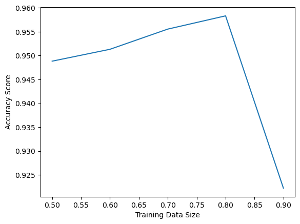

```python
# Plot accuracy score vs training size
plt.plot([0.9, 0.8, 0.7, 0.6, 0.5], [accuracy1, accuracy2, accuracy3, accuracy4, accuracy5])
plt.xlabel("Training Data Size")
plt.ylabel("Accuracy Score");
```

### Q4. What have you learned about the effect of training size on accuracy score? Why might it be a bad idea to have a training size near 1.0?

Answer: I have learned that training size should be much more than half of the dataset, ideally around 70 or 80% of the dataset, in order to create a model which achieves the highest level of accuracy. However, when training size gets closer to 1.0, the risk of overfitting increases, making the model less usefull for predicting on out-of-sample data.

### Q5. Train a `RandomForestClassifier` model on the Q1 split dataset that had a train_size of 0.7. Create six different models with different `n_estimators` = 2, 4, 8, 16, 32, 64. Fit your model on the training data set and predict on the test data set. Calculate an accuracy score. Save each accuracy score in a variable and print the accuracy score.

```python
# Get the model, fit and predict
model_rf1 = RandomForestClassifier(n_estimators=2)
y_model_rf1 = model_rf1.fit(Xtrain3, ytrain3).predict(Xtest3)
# calculating accuracy score
accuracyrf1 = accuracy_score(ytest3, y_model_rf1)

# Get the model, fit and predict
model_rf2 = RandomForestClassifier(n_estimators=4)
y_model_rf2 = model_rf2.fit(Xtrain3, ytrain3).predict(Xtest3)
# calculating accuracy score
accuracyrf2 = accuracy_score(ytest3, y_model_rf2)

# Get the model, fit and predict
model_rf3 = RandomForestClassifier(n_estimators=8)
y_model_rf3 = model_rf3.fit(Xtrain3, ytrain3).predict(Xtest3)
# calculating accuracy score
accuracyrf3 = accuracy_score(ytest3, y_model_rf3)

# Get the model, fit and predict
model_rf4 = RandomForestClassifier(n_estimators=16)
y_model_rf4 = model_rf4.fit(Xtrain3, ytrain3).predict(Xtest3)
# calculating accuracy score
accuracyrf4 = accuracy_score(ytest3, y_model_rf4)

# Get the model, fit and predict
model_rf5 = RandomForestClassifier(n_estimators=32)
y_model_rf5 = model_rf5.fit(Xtrain3, ytrain3).predict(Xtest3)
# calculating accuracy score
accuracyrf5 = accuracy_score(ytest3, y_model_rf5)

# Get the model, fit and predict
model_rf6 = RandomForestClassifier(n_estimators=64)
y_model_rf6 = model_rf6.fit(Xtrain3, ytrain3).predict(Xtest3)
# calculating accuracy score
accuracyrf6 = accuracy_score(ytest3, y_model_rf6)

print("2 Trees Accuracy score:", accuracyrf1)
print("4 Trees Accuracy score:", accuracyrf2)
print("8 Trees Accuracy score:", accuracyrf3)
print("16 Trees Accuracy score:", accuracyrf4)
print("32 Trees Accuracy score:", accuracyrf5)
print("64 Trees Accuracy score:", accuracyrf6)
```

```
2 Trees Accuracy score: 0.7333333333333333
4 Trees Accuracy score: 0.8888888888888888
8 Trees Accuracy score: 0.9314814814814815
16 Trees Accuracy score: 0.9666666666666667
32 Trees Accuracy score: 0.9666666666666667
64 Trees Accuracy score: 0.9740740740740741
```

### Q6. Make a plot with `n_estimators` on the x axis and accuracy score on the y-axis. Label the x and y axes.

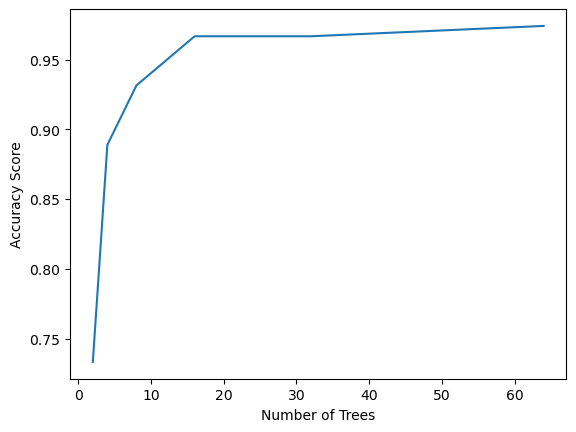

```python
# Plot accuracy score vs training size
plt.plot([2, 4, 8, 16, 32, 64], [accuracyrf1, accuracyrf2, accuracyrf3, accuracyrf4, accuracyrf5, accuracyrf6])
plt.xlabel("Number of Trees")
plt.ylabel("Accuracy Score");
```

### Q7. What have you learned about `n_estimators`?

Answer: As the number of trees in a random forest model increases, the model generally performs better. However, once the number of trees is large enough, the improvement in performance becomes smaller with each additional tree, and this may make adding more trees not worth it if time or computing power is an issue.

### Save your notebook and output an html version. To receive credit for this in-class exercise upload both the .html and .ipynb files.